# FAO aquastat database - Agricultural water withdrawal (% of total)

This is a short breakdown of the FAO aquastat database reports on agricultural water withdrawal as percentage of the total water usage. Most of the R commands have been made visible for clarity.

The dataset is of the following type:

```r
water <- read.csv('water.csv', stringsAsFactors = FALSE)
head(water)
```

```
##          country X1962 X1967 X1972 X1977 X1982 X1987 X1992 X1997 X2002
## 1    Afghanistan    NA    NA    NA    NA    NA    99    NA    NA    98
## 2        Albania    NA    NA    NA    NA    NA    NA    80    NA    61
## 3        Algeria    NA    NA    NA    NA    74    NA    60    NA    64
## 4 American Samoa    NA    NA    NA    NA    NA    NA    NA    NA    NA
## 5        Andorra    NA    NA    NA    NA    NA    NA    NA    NA    NA
## 6         Angola    NA    NA    NA    NA    NA    76    NA    NA    60
##   X2007
## 1    NA
## 2    NA
## 3    NA
## 4    NA
## 5    NA
## 6    NA
```

The total number of countries in the dataset is:

```r
nrow(water)
```

```
## [1] 228
```

A list of all the countries is given at the end of this document. There is quite some missing data as can be seen in the data example.

Using tidyr it is easy to tidy up the dataset:

```r
observations <- gather(water, "year", "percentage", 2:11) %>%
  filter(!is.na(percentage)) %>%
  mutate(year = as.integer(substring(year, 2)))

head(observations)
```

```
##     country year percentage
## 1   Uruguay 1967       91.0
## 2     Ghana 1972       52.0
## 3    Israel 1972       79.8
## 4     Italy 1972       60.0
## 5    Uganda 1972       60.0
## 6 Venezuela 1972       46.0
```

The total number of observations is:

```r
observations %>%
  summarise(N = n())
```

```
##     N
## 1 351
```

A breakdown per year gives the following number of observations:

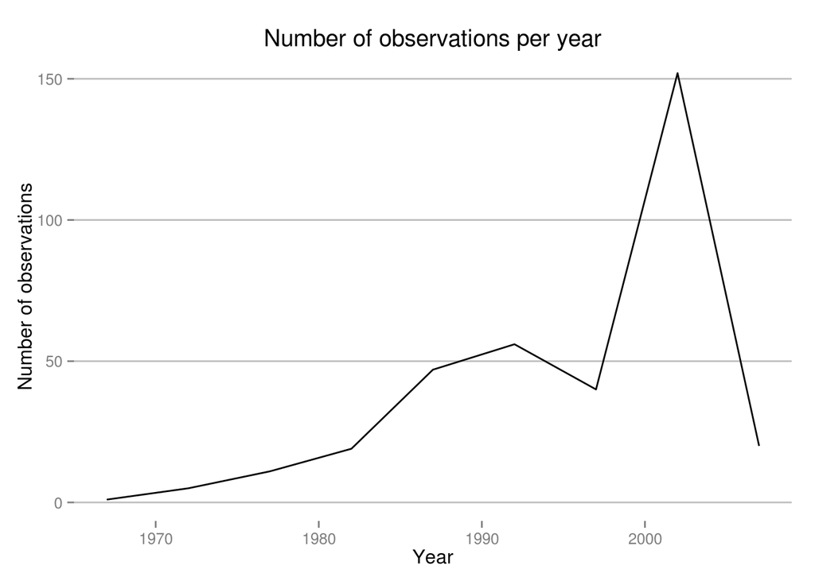

```r
ggplot(aes(x = year, y = count), data = observations %>% group_by(year) %>% summarise(count = n()) )+
  geom_line() + theme_hc() +
  xlab("Year") + ylab("Number of observations") +
  ggtitle("Number of observations per year")
```

There seems to a trend towards more observations, but this trend is not persistent. The counts are done every five years from 1967 to 2007.

The average withdrawal over the years is as follows:

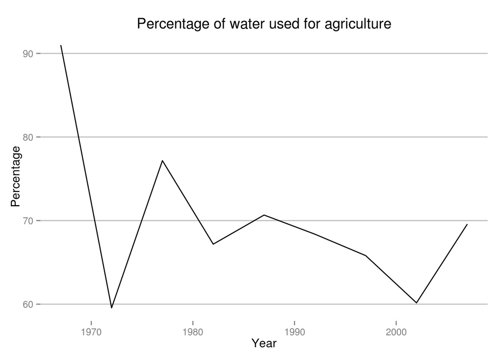

```r
ggplot(aes(x = year, y = avg), data = observations %>% group_by(year) %>% summarise(avg = mean(percentage)))+
  geom_line() + theme_hc() +
  xlab("Year") + ylab("Percentage") +
  ggtitle("Percentage of water used for agriculture")
```

Even though the food production has been rising, the percentage of water used for agriculture is falling. There is a reasonable chance that the total amount of water usage has been rising.

The top 10 countries with the highest average percentage water withdrawal for argiculture are:

```r
observations %>% group_by(country) %>% summarise(avg = mean(percentage)) %>% top_n(10, avg)
```

```
## Source: local data frame [10 x 2]
##
##         country      avg
##           (chr)    (dbl)
## 1   Afghanistan 98.50000
## 2    Bangladesh 96.00000
## 3       Eritrea 95.00000
## 4    Madagascar 97.00000
## 5       Myanmar 98.00000
## 6         Nepal 96.00000
## 7       Somalia 98.46667
## 8     Swaziland 95.75000
## 9      Thailand 95.00000
## 10 Turkmenistan 97.86667
```

These seem to be relatively undeveloped countries. There might be two underlying factors: * Developed countries have a higher water usage * Developed countries use water more efficient in agriculture

If we would take this percentage as a proxy for development, then decreasing water withdrawal would indicate development. The top ten developing nations would then be:

```r
observations %>%
  group_by(country) %>%
  arrange(year) %>%
  filter(row_number()==1 | row_number()==n()) %>%
  filter(n() > 1) %>%
  summarise(delta = first(percentage) - last(percentage))  %>%
  top_n(10, delta)
```

```
## Source: local data frame [10 x 2]
##
##           country delta
##             (chr) (dbl)
## 1          Belize 70.00
## 2      Costa Rica 27.10
## 3        Djibouti 71.72
## 4  Dominican Rep. 22.50
## 5          Gambia 26.00
## 6            Iraq 27.00
## 7         Jamaica 37.30
## 8         Lebanon 25.90
## 9         Lesotho 36.00
## 10        Vietnam 24.00
```

These are the participating countries:

```r
water$country
```

```
##   [1] "Afghanistan"                      "Albania"
##   [3] "Algeria"                          "American Samoa"
##   [5] "Andorra"                          "Angola"
##   [7] "Anguilla"                         "Antigua and Barbuda"
##   [9] "Argentina"                        "Armenia"
##  [11] "Aruba"                            "Australia"
##  [13] "Austria"                          "Azerbaijan"
##  [15] "Bahamas"                          "Bahrain"
##  [17] "Bangladesh"                       "Barbados"
##  [19] "Belarus"                          "Belgium"
##  [21] "Belgium"                          "Belize"
##  [23] "Benin"                            "Bermuda"
##  [25] "Bhutan"                           "Bolivia"
##  [27] "Bosnia and Herzegovina"           "Botswana"
##  [29] "Brazil"                           "British Virgin Islands"
```

[output cut: 99 more lines]